# Metabolic Syndrome

## Modeli mašinskog učenja

Za pravljenje naših modela koristićemo Logističku regresiju, Stabla odlučivanja i Random Forest algoritam. Odlučili smo se za dva jednostavnija pristupa i jedan složeniji pa ćemo na kraju uporediti rezultate.

#### Logistička regresija

```r
set.seed(1)
split <- initial_split(data, prop = 0.8, strata = MetabolicSyndrome)
train <- training(split)
test <- testing(split)

train_control <- trainControl(method = "cv", number = 10)

model <- train(MetabolicSyndrome ~ BMI_category + Albuminuria_New + Diabetes + HDL*Triglycerides + Marital + Race,
               data = train,
               method = "glm",
               family = "binomial",
               trControl = train_control)

print(model)
```

```
Generalized Linear Model

1920 samples
   7 predictor
   2 classes: 'No', 'Yes'

No pre-processing
Resampling: Cross-Validated (10 fold)
Summary of sample sizes: 1727, 1729, 1728, 1727, 1728, 1729, ...
Resampling results:

  Accuracy   Kappa
  0.8348778  0.6301554
```

```r
pred_prob <- predict(model, newdata = test, type = "raw")

cm <- confusionMatrix(pred_prob, test$MetabolicSyndrome)

print(cm)
```

```
Confusion Matrix and Statistics

          Reference
Prediction  No Yes
       No  282  40
       Yes  34 125

               Accuracy : 0.8462
                 95% CI : (0.8108, 0.8772)
    No Information Rate : 0.657
    P-Value [Acc > NIR] : <2e-16

                  Kappa : 0.6557

 Mcnemar's Test P-Value : 0.5611

            Sensitivity : 0.8924
            Specificity : 0.7576
         Pos Pred Value : 0.8758
         Neg Pred Value : 0.7862
             Prevalence : 0.6570
         Detection Rate : 0.5863
   Detection Prevalence : 0.6694
      Balanced Accuracy : 0.8250

       'Positive' Class : No
```

```r
precision <- cm$byClass["Pos Pred Value"]
recall <- cm$byClass["Sensitivity"]
f1_score <- 2 * ((precision * recall) / (precision + recall))

cat("F1 score:", round(f1_score, 4), "\n")
```

```
F1 score: 0.884
```

Naš model logističke regresije dobio je F1 score od 0.884 što je dobar rezultat.

## Stablo odlučivanja

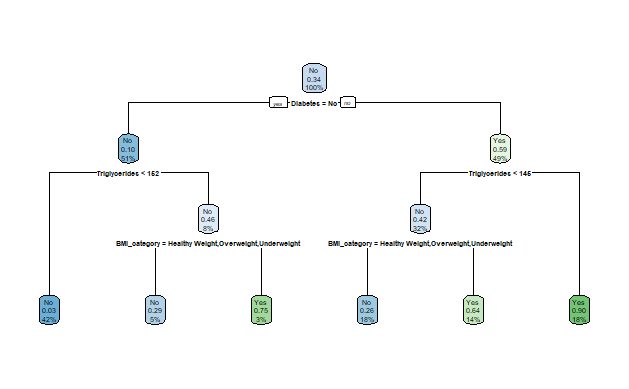

```r
tree <- rpart(MetabolicSyndrome ~ BMI_category + Albuminuria_New + Diabetes + Triglycerides,
              data = train,
              method = "class")

rpart.plot(tree)
```

```r
print(model)
```

```
Generalized Linear Model

1920 samples
   7 predictor
   2 classes: 'No', 'Yes'

No pre-processing
Resampling: Cross-Validated (10 fold)
Summary of sample sizes: 1727, 1729, 1728, 1727, 1728, 1729, ...
Resampling results:

  Accuracy   Kappa
  0.8348778  0.6301554
```

```r
pred_prob <- predict(model, newdata = test, type = "raw")

cm <- confusionMatrix(pred_prob, test$MetabolicSyndrome)
print(cm)
```

```
Confusion Matrix and Statistics

          Reference
Prediction  No Yes
       No  282  40
       Yes  34 125

               Accuracy : 0.8462
                 95% CI : (0.8108, 0.8772)
    No Information Rate : 0.657
    P-Value [Acc > NIR] : <2e-16

                  Kappa : 0.6557

 Mcnemar's Test P-Value : 0.5611

            Sensitivity : 0.8924
            Specificity : 0.7576
         Pos Pred Value : 0.8758
         Neg Pred Value : 0.7862
             Prevalence : 0.6570
         Detection Rate : 0.5863
   Detection Prevalence : 0.6694
      Balanced Accuracy : 0.8250

       'Positive' Class : No
```

```r
precision <- cm$byClass["Pos Pred Value"]
recall <- cm$byClass["Sensitivity"]
f1_score <- 2 * ((precision * recall) / (precision + recall))

cat("F1 score:", round(f1_score, 4), "\n")
```

```
F1 score: 0.884
```

## Random forest

```r
model <- train(MetabolicSyndrome ~ BMI_category + Albuminuria_New + Diabetes + HDL*Triglycerides + Marital + Race,
                  data = train,
                  method = "rf",
                  trControl = train_control)

print(model)
```

```
Random Forest

1920 samples
   7 predictor
   2 classes: 'No', 'Yes'

No pre-processing
Resampling: Cross-Validated (10 fold)
Summary of sample sizes: 1727, 1729, 1728, 1728, 1728, 1729, ...
Resampling results across tuning parameters:

  mtry  Accuracy   Kappa
   2    0.8343586  0.6095582
  10    0.8353896  0.6327960
  19    0.8307101  0.6236792

Accuracy was used to select the optimal model using the largest value.
The final value used for the model was mtry = 10.
```

```r
pred_prob <- predict(model, newdata = test, type = "raw")

cm <- confusionMatrix(pred_prob, test$MetabolicSyndrome)

print(cm)
```

```
Confusion Matrix and Statistics

          Reference
Prediction  No Yes
       No  283  40
       Yes  33 125

               Accuracy : 0.8482
                 95% CI : (0.813, 0.8791)
    No Information Rate : 0.657
    P-Value [Acc > NIR] : <2e-16

                  Kappa : 0.6598

 Mcnemar's Test P-Value : 0.4825

            Sensitivity : 0.8956
            Specificity : 0.7576
         Pos Pred Value : 0.8762
         Neg Pred Value : 0.7911
             Prevalence : 0.6570
         Detection Rate : 0.5884
   Detection Prevalence : 0.6715
      Balanced Accuracy : 0.8266

       'Positive' Class : No
```

```r
precision <- cm$byClass["Pos Pred Value"]
recall <- cm$byClass["Sensitivity"]
f1_score <- 2 * ((precision * recall) / (precision + recall))

cat("F1 score:", round(f1_score, 4), "\n")
```

```
F1 score: 0.8858
```

Naš Random Forest algoritam daje najbolji F1 score ali je to neznatna razlika. Primenićemo neke promene i videćemo da li će naši modeli bolje raditi.

## Poboljšanje modela

Hajde da kolonu Marital probamo da popunimo metodom najbližih suseda.

```r
sum(is.na(dataPom$Marital) | dataPom$Marital == "")
```

```
[1] 208
```

```r
dataPom <- dataPom %>% mutate(Marital = ifelse(Marital == "", NA, Marital))

sum(is.na(dataPom$Marital))
```

```
[1] 208
```

```r
data_imputed <- kNN(dataPom, variable = "Marital", k = 5)
sum(is.na(data_imputed$Marital))
```

```
[1] 0
```

```r
data$Marital = factor(data_imputed$Marital)
summary(data)
```

```
      seqn            Age            Sex            Marital         Income              Race
 Min.   :62161   Min.   :20.00   Female:1211   Divorced : 254   Min.   : 300   Asian      :349
 1st Qu.:64591   1st Qu.:34.00   Male  :1190   Married  :1318   1st Qu.:1600   Black      :548
 Median :67059   Median :48.00                 Separated: 103   Median :2500   Hispanic   :257
 Mean   :67031   Mean   :48.69                 Single   : 557   Mean   :3932   MexAmerican:253
 3rd Qu.:69495   3rd Qu.:63.00                 Widowed  : 169   3rd Qu.:6200   Other      : 61
 Max.   :71915   Max.   :80.00                                  Max.   :9000   White      :933
   WaistCirc           BMI         Albuminuria        UrAlbCr           UricAcid       BloodGlucose
 Min.   : 56.20   Min.   :13.40   Min.   :0.0000   Min.   :   1.40   Min.   : 1.800   Min.   : 39.0
 1st Qu.: 87.00   1st Qu.:24.00   1st Qu.:0.0000   1st Qu.:   4.45   1st Qu.: 4.500   1st Qu.: 92.0
 Median : 97.00   Median :27.70   Median :0.0000   Median :   7.07   Median : 5.400   Median : 99.0
 Mean   : 98.26   Mean   :28.69   Mean   :0.1541   Mean   :  43.63   Mean   : 5.489   Mean   :108.2
 3rd Qu.:107.20   3rd Qu.:32.00   3rd Qu.:0.0000   3rd Qu.:  13.69   3rd Qu.: 6.400   3rd Qu.:110.0
 Max.   :176.00   Max.   :68.70   Max.   :2.0000   Max.   :5928.00   Max.   :11.300   Max.   :382.0
      HDL         Triglycerides    MetabolicSyndrome         BMI_category Albuminuria_New
 Min.   : 14.00   Min.   :  26.0   No :1579          Healthy Weight:704   0:2089
 1st Qu.: 43.00   1st Qu.:  75.0   Yes: 822          Obese         :857   1: 254
 Median : 51.00   Median : 103.0                     Overweight    :792   2:  58
 Mean   : 53.37   Mean   : 128.1                     Underweight   : 48
 3rd Qu.: 62.00   3rd Qu.: 150.0
 Max.   :156.00   Max.   :1562.0
            UrAlbCr_New          Diabetes                  HDL_New               Triglycerides_New
 Above 30         : 311   No         :1204   Above 100         :  16   Above 500          : 859
 Between 10 and 30: 537   Prediabetes: 893   Between 50 and 100:1302   Between 125 and 500:  18
 Under 10         :1553   Yes        : 304   Under 50          :1083   Under 125          :1524



 BMI_WaistCirc_ratio
 Min.   :0.1402
 1st Qu.:0.2701
 Median :0.2867
 Mean   :0.2903
 3rd Qu.:0.3063
 Max.   :0.6474
```

```r
table(data$Marital)
```

```
 Divorced   Married Separated    Single   Widowed
      254      1318       103       557       169
```

S obzirom da u svim modelima koristimo BMI_Category, hajde da probamo na drugaciji način da popunimo ovu promenjivu i da vidimo da li će to uticati na naše modele.

```r
dataPom$BMI_Category <- ifelse(dataPom$BMI < 18.5, "Underweight",
                            ifelse(dataPom$BMI >= 18.5 & dataPom$BMI <= 24.9, "Healthy Weight",
                                   ifelse(dataPom$BMI >= 25.0 & dataPom$BMI <= 29.9, "Overweight",
                                          "Obese")))
dataPom$BMI_category <- factor(dataPom$BMI_category)
data_imputed <- kNN(dataPom, variable = "BMI_Category", k = 5)
sum(is.na(data_imputed$BMI_Category))
```

```
[1] 0
```

```r
data$BMI_category = factor(data_imputed$BMI_Category)
summary(data)
```

```
      seqn            Age            Sex            Marital         Income              Race
 Min.   :62161   Min.   :20.00   Female:1211   Divorced : 254   Min.   : 300   Asian      :349
 1st Qu.:64591   1st Qu.:34.00   Male  :1190   Married  :1318   1st Qu.:1600   Black      :548
 Median :67059   Median :48.00                 Separated: 103   Median :2500   Hispanic   :257
 Mean   :67031   Mean   :48.69                 Single   : 557   Mean   :3932   MexAmerican:253
 3rd Qu.:69495   3rd Qu.:63.00                 Widowed  : 169   3rd Qu.:6200   Other      : 61
 Max.   :71915   Max.   :80.00                                  Max.   :9000   White      :933
   WaistCirc           BMI         Albuminuria        UrAlbCr           UricAcid       BloodGlucose
 Min.   : 56.20   Min.   :13.40   Min.   :0.0000   Min.   :   1.40   Min.   : 1.800   Min.   : 39.0
 1st Qu.: 87.00   1st Qu.:24.00   1st Qu.:0.0000   1st Qu.:   4.45   1st Qu.: 4.500   1st Qu.: 92.0
 Median : 97.00   Median :27.70   Median :0.0000   Median :   7.07   Median : 5.400   Median : 99.0
 Mean   : 98.26   Mean   :28.69   Mean   :0.1541   Mean   :  43.63   Mean   : 5.489   Mean   :108.2
 3rd Qu.:107.20   3rd Qu.:32.00   3rd Qu.:0.0000   3rd Qu.:  13.69   3rd Qu.: 6.400   3rd Qu.:110.0
 Max.   :176.00   Max.   :68.70   Max.   :2.0000   Max.   :5928.00   Max.   :11.300   Max.   :382.0
      HDL         Triglycerides    MetabolicSyndrome         BMI_category Albuminuria_New
 Min.   : 14.00   Min.   :  26.0   No :1579          Healthy Weight:712   0:2089
 1st Qu.: 43.00   1st Qu.:  75.0   Yes: 822          Obese         :875   1: 254
 Median : 51.00   Median : 103.0                     Overweight    :766   2:  58
 Mean   : 53.37   Mean   : 128.1                     Underweight   : 48
 3rd Qu.: 62.00   3rd Qu.: 150.0
 Max.   :156.00   Max.   :1562.0
            UrAlbCr_New          Diabetes                  HDL_New               Triglycerides_New
 Above 30         : 311   No         :1204   Above 100         :  16   Above 500          : 859
 Between 10 and 30: 537   Prediabetes: 893   Between 50 and 100:1302   Between 125 and 500:  18
 Under 10         :1553   Yes        : 304   Under 50          :1083   Under 125          :1524



 BMI_WaistCirc_ratio
 Min.   :0.1402
 1st Qu.:0.2701
 Median :0.2867
 Mean   :0.2903
 3rd Qu.:0.3063
 Max.   :0.6474
```

```r
table(data$BMI_category)
```

```
Healthy Weight          Obese     Overweight    Underweight
           712            875            766             48
```

Ovu promenjivu smo popunili isto kao Marital, pomoću KNN algoritma. Hajde da vidimo da li postoje poboljšanja naših modela.

```r
model <- train(MetabolicSyndrome ~ BMI_category + Albuminuria_New + Diabetes + HDL*Triglycerides + Marital + Race,
               data = train,
               method = "glm",
               family = "binomial",
               trControl = train_control)

print(model)
```

```
Generalized Linear Model

1920 samples
   7 predictor
   2 classes: 'No', 'Yes'

No pre-processing
Resampling: Cross-Validated (10 fold)
Summary of sample sizes: 1728, 1729, 1728, 1728, 1728, 1729, ...
Resampling results:

  Accuracy   Kappa
  0.8306976  0.6213261
```

```r
pred_prob <- predict(model, newdata = test, type = "raw")

cm <- confusionMatrix(pred_prob, test$MetabolicSyndrome)

print(cm)
```

```
Confusion Matrix and Statistics

          Reference
Prediction  No Yes
       No  282  40
       Yes  34 125

               Accuracy : 0.8462
                 95% CI : (0.8108, 0.8772)
    No Information Rate : 0.657
    P-Value [Acc > NIR] : <2e-16

                  Kappa : 0.6557

 Mcnemar's Test P-Value : 0.5611

            Sensitivity : 0.8924
            Specificity : 0.7576
         Pos Pred Value : 0.8758
         Neg Pred Value : 0.7862
             Prevalence : 0.6570
         Detection Rate : 0.5863
   Detection Prevalence : 0.6694
      Balanced Accuracy : 0.8250

       'Positive' Class : No
```

```r
precision <- cm$byClass["Pos Pred Value"]
recall <- cm$byClass["Sensitivity"]
f1_score <- 2 * ((precision * recall) / (precision + recall))

cat("F1 score:", round(f1_score, 4), "\n")
```

```
F1 score: 0.884
```

Logistička regresija radi na isti način kao i pre.

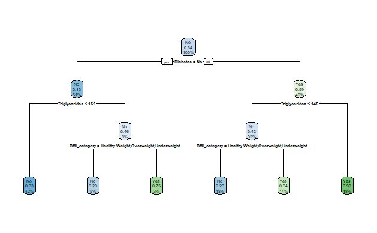

```r
tree <- rpart(MetabolicSyndrome ~ BMI_category + Albuminuria_New + Diabetes + Triglycerides,
              data = train,
              method = "class")

rpart.plot(tree)
```

```r
print(model)
```

```
Generalized Linear Model

1920 samples
   7 predictor
   2 classes: 'No', 'Yes'

No pre-processing
Resampling: Cross-Validated (10 fold)
Summary of sample sizes: 1728, 1729, 1728, 1728, 1728, 1729, ...
Resampling results:

  Accuracy   Kappa
  0.8306976  0.6213261
```

```r
pred_prob <- predict(model, newdata = test, type = "raw")

cm <- confusionMatrix(pred_prob, test$MetabolicSyndrome)
print(cm)
```

```
Confusion Matrix and Statistics

          Reference
Prediction  No Yes
       No  282  40
       Yes  34 125

               Accuracy : 0.8462
                 95% CI : (0.8108, 0.8772)
    No Information Rate : 0.657
    P-Value [Acc > NIR] : <2e-16

                  Kappa : 0.6557

 Mcnemar's Test P-Value : 0.5611

            Sensitivity : 0.8924
            Specificity : 0.7576
         Pos Pred Value : 0.8758
         Neg Pred Value : 0.7862
             Prevalence : 0.6570
         Detection Rate : 0.5863
   Detection Prevalence : 0.6694
      Balanced Accuracy : 0.8250

       'Positive' Class : No
```

```r
precision <- cm$byClass["Pos Pred Value"]
recall <- cm$byClass["Sensitivity"]
f1_score <- 2 * ((precision * recall) / (precision + recall))

cat("F1 score:", round(f1_score, 4), "\n")
```

```
F1 score: 0.884
```

```r
model <- train(MetabolicSyndrome ~ BMI_category + Albuminuria_New + Diabetes + HDL*Triglycerides + Marital + Race,
                  data = train,
                  method = "rf",
                  trControl = train_control)

print(model)
```

```
Random Forest

1920 samples
   7 predictor
   2 classes: 'No', 'Yes'

No pre-processing
Resampling: Cross-Validated (10 fold)
Summary of sample sizes: 1729, 1728, 1728, 1728, 1728, 1727, ...
Resampling results across tuning parameters:

  mtry  Accuracy   Kappa
   2    0.8364730  0.6118744
  10    0.8354393  0.6335051
  19    0.8302364  0.6237085

Accuracy was used to select the optimal model using the largest value.
The final value used for the model was mtry = 2.
```

```r
pred_prob <- predict(model, newdata = test, type = "raw")

cm <- confusionMatrix(pred_prob, test$MetabolicSyndrome)

print(cm)
```

```
Confusion Matrix and Statistics

          Reference
Prediction  No Yes
       No  301  53
       Yes  15 112

               Accuracy : 0.8586
                 95% CI : (0.8242, 0.8885)
    No Information Rate : 0.657
    P-Value [Acc > NIR] : < 2.2e-16

                  Kappa : 0.6681

 Mcnemar's Test P-Value : 7.226e-06

            Sensitivity : 0.9525
            Specificity : 0.6788
         Pos Pred Value : 0.8503
         Neg Pred Value : 0.8819
             Prevalence : 0.6570
         Detection Rate : 0.6258
   Detection Prevalence : 0.7360
      Balanced Accuracy : 0.8157

       'Positive' Class : No
```

```r
precision <- cm$byClass["Pos Pred Value"]
recall <- cm$byClass["Sensitivity"]
f1_score <- 2 * ((precision * recall) / (precision + recall))

cat("F1 score:", round(f1_score, 4), "\n")
```

```
F1 score: 0.8985
```

## Zaključak

Rezultati pokazuju da model dobro predviđa metabolički sindrom. Matrica konfuzije je pokazala tačne identifikacije pacijenata sa i bez metaboličkog sindroma, ali je bilo i nekih grešaka, što znači da ima prostora za poboljšanje.

U budućnosti, mogli bismo isprobati složenije modele, kao što su ansambl metode ili neuronske mreže, kako bismo poboljšali predikcije. Takođe, koristili bismo raznovrsnije skupove podataka i proveravali model na eksternim podacima kako bismo ocenili koliko je model univerzalan.